# Predicting Heart Disease Based on Relevant Body Data in Switzerland

### Group member:

Anyna Wang 53713814

Lindsay Watson 62396171

Yiman Ma

## Introduction:

##### background information

Many people do not know they have heart disease until it happens; however, with modern technology, we can predict how likely people are to have heart disease based on information like age, blood pressure and heart rate. Thus, patients can prevent and monitor their heart health in advance. “It has been shown that increase in heart rate by 10 beats per minute was associated with an increase in the risk of cardiac death, and this increase in the risk is similar with an increase in systolic blood pressure by 10 mm Hg” (Perret-Guillaume et al., 2009).

##### state the question

Therefore, our question is, are age, maximum heart rate, and blood pressure strongly associated with the diagnosis of heart disease? If so, can we accurately predict the diagnosis of heart disease with these three predictors? KNN binary classification algorithm will be used to predict the diagnosis. We will also estimate the accuracy of our model to predict the disease.

## Preliminary exploratory data analysis:

```r
### Run this cell before continuing.
library(tidyverse)
library(tidymodels)
library(digest)
library(repr)
library(ggplot2)
library(cowplot)
options(repr.matrix.max.rows = 6)
```

```
• Learn how to get started at https://www.tidymodels.org/start/
```

#### 1. read data from the web into R and clean the dataset

```r
# The url is a copy link of heart disease data set from UCI Machine Learning Repository website.
url <- "https://archive.ics.uci.edu/ml/machine-learning-databases/heart-disease/processed.switzerland.data"

# Naming each columns based on the information from UCI Machine Learning Repository.
names <- c("age",
           "sex",
           "chest_pain_type",
           "resting_blood_pressure",
           "serum_cholestoral (mg/dl)",
           "fasting_blood_sugar",
           "resting_electrocardiographic_results",
           "maximum_heart_rate",
           "exercise_induced_angina",
           "ST_depression",
           "slope_of_the_peak_exercise_ST_segment",
           "number_of_major_vessels",
           "thal",
           "diagnosis_of_heart_disease")

# Loading processed switzerland heart disease data set
original_switzerland_data <- read_delim(url, delim = ",", col_names = names) |>

                             # making categorie variables as a factor
                             mutate(across(sex : chest_pain_type, as_factor)) |>
                             mutate(across(fasting_blood_sugar : resting_electrocardiographic_results, as_factor)) |>
                             mutate(exercise_induced_angina = as_factor(exercise_induced_angina)) |>
                             mutate(slope_of_the_peak_exercise_ST_segment = as_factor(slope_of_the_peak_exercise_ST_segment)) |>
                             mutate(thal = as_factor(thal)) |>

                             # making age as a integer, because it can't have negative and decimals.
                             mutate(age = as.integer(age)) |>

                             # making number of major vessels as integer, because it has a range with 0-3.
                             mutate(number_of_major_vessels = as.integer(number_of_major_vessels)) |>

                             # making quantitative variables as a double
                             mutate(resting_blood_pressure = as.double(resting_blood_pressure)) |>
                             mutate(maximum_heart_rate = as.double(maximum_heart_rate)) |>
                             mutate(ST_depression = as.double(ST_depression))

# If diagnosis of heart disease is 0
original_switzerland_data$diagnosis_of_heart_disease <- ifelse(original_switzerland_data$diagnosis_of_heart_disease == 0, "false", "true")

# It is impossible to have 0 blood pressure, delate the impossible data.
# Making diagnosis of heart disease as factor
original_switzerland_data <- original_switzerland_data |>
                             filter(resting_blood_pressure != 0) |>
                             mutate(diagnosis_of_heart_disease = as_factor(diagnosis_of_heart_disease))

# Data can not be "?", replace "?" to NA
original_switzerland_data <- replace(original_switzerland_data , original_switzerland_data == "?", NA)

# First 6 row of the data set
head(original_switzerland_data)
```

```
Warning message in mask$eval_all_mutate(quo):
“NAs introduced by coercion”
Warning message in mask$eval_all_mutate(quo):
“NAs introduced by coercion”
Warning message in mask$eval_all_mutate(quo):
“NAs introduced by coercion”
Warning message in mask$eval_all_mutate(quo):
“NAs introduced by coercion”
```

A tibble: 6 × 14

| age <int> | sex <fct> | chest_pain_type <fct> | resting_blood_pressure <dbl> | serum_cholestoral (mg/dl) <dbl> | fasting_blood_sugar <fct> | resting_electrocardiographic_results <fct> | maximum_heart_rate <dbl> | exercise_induced_angina <fct> | ST_depression <dbl> | slope_of_the_peak_exercise_ST_segment <fct> | number_of_major_vessels <int> | thal <fct> | diagnosis_of_heart_disease <fct> |
| --- | --- | --- | --- | --- | --- | --- | --- | --- | --- | --- | --- | --- | --- |
| 32 | 1 | 1 | 95 | 0 | NA | 0 | 127 | 0 | 0.7 | 1 | NA | NA | true |
| 34 | 1 | 4 | 115 | 0 | NA | NA | 154 | 0 | 0.2 | 1 | NA | NA | true |
| 36 | 1 | 4 | 110 | 0 | NA | 0 | 125 | 1 | 1.0 | 2 | NA | 6 | true |
| 38 | 0 | 4 | 105 | 0 | NA | 0 | 166 | 0 | 2.8 | 1 | NA | NA | true |
| 38 | 0 | 4 | 110 | 0 | 0 | 0 | 156 | 0 | 0.0 | 2 | NA | 3 | true |
| 38 | 1 | 3 | 100 | 0 | NA | 0 | 179 | 0 | -1.1 | 1 | NA | NA | false |

#### 2. wrangle data set

```r
# wrangle data set, select the columns that the research will use.
switzerland_heart_disease_data <- original_switzerland_data |>
             select(age, resting_blood_pressure, maximum_heart_rate, diagnosis_of_heart_disease)

head(switzerland_heart_disease_data)
```

A tibble: 6 × 4

| age <int> | resting_blood_pressure <dbl> | maximum_heart_rate <dbl> | diagnosis_of_heart_disease <fct> |
| --- | --- | --- | --- |
| 32 | 95 | 127 | true |
| 34 | 115 | 154 | true |
| 36 | 110 | 125 | true |
| 38 | 105 | 166 | true |
| 38 | 110 | 156 | true |
| 38 | 100 | 179 | false |

#### 3. summarize data in table

```r
# Making the training data
heart_disease_split <- initial_split(switzerland_heart_disease_data, prop = 0.75, strata = diagnosis_of_heart_disease)
heart_disease_training_data <- training(heart_disease_split)

heart_disease_training_data
```

A tibble: 90 × 4

| age <int> | resting_blood_pressure <dbl> | maximum_heart_rate <dbl> | diagnosis_of_heart_disease <fct> |
| --- | --- | --- | --- |
| 32 | 95 | 127 | true |
| 34 | 115 | 154 | true |
| 36 | 110 | 125 | true |
| ⋮ | ⋮ | ⋮ | ⋮ |
| 70 | 140 | 157 | true |
| 73 | 160 | 121 | true |
| 74 | 145 | 123 | true |

```r
# Counting rows that have missing data
data_missing_num <- heart_disease_training_data|>
                    map_df(is.na)|>
                    map_df(sum)
data_missing_num

# Counting rows that have data, calculating the mean of age, mean of blood pressure and mean of maximum heart rate
heart_disease_summarize <- heart_disease_training_data|>
                           group_by(diagnosis_of_heart_disease) |>
                           summarize(n_age = sum(!is.na(age)),
                                     n_resting_blood_pressure = sum(!is.na(resting_blood_pressure)),
                                     n_maximum_heart_rate = sum(!is.na(maximum_heart_rate)),
                                     n_diagnosis_of_heart_disease = sum(!is.na(diagnosis_of_heart_disease)),
                                     mean_age = mean(age, na.rm=TRUE),
                                     mean_blood_pressure = mean(resting_blood_pressure, na.rm=TRUE),
                                     mean_heart_rate = mean(maximum_heart_rate, na.rm=TRUE))
heart_disease_summarize
```

A tibble: 1 × 4

| age <int> | resting_blood_pressure <int> | maximum_heart_rate <int> | diagnosis_of_heart_disease <int> |
| --- | --- | --- | --- |
| 0 | 0 | 0 | 0 |

A tibble: 2 × 8

| diagnosis_of_heart_disease <fct> | n_age <int> | n_resting_blood_pressure <int> | n_maximum_heart_rate <int> | n_diagnosis_of_heart_disease <int> | mean_age <dbl> | mean_blood_pressure <dbl> | mean_heart_rate <dbl> |
| --- | --- | --- | --- | --- | --- | --- | --- |
| true | 83 | 83 | 83 | 83 | 55.90361 | 131.0843 | 120.4096 |
| false | 7 | 7 | 7 | 7 | 52.14286 | 119.2857 | 139.8571 |

#### 4. visualization data

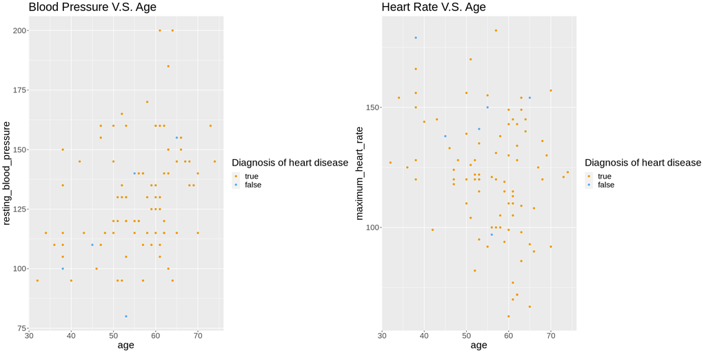

```r
# Create a scatterplot to visualize the relationship between two quantitative variables, categorized by the presence or
# absence of heart disease
# The following creates 2 scatterplots: Blood Pressure V.S. Age, Heart Rate V.S. Age
Age_BP <- heart_disease_training_data |>
    ggplot(aes(x = age, y = resting_blood_pressure, color = diagnosis_of_heart_disease)) +
    geom_point(alpha = 5) +
    labs(color = "Diagnosis of heart disease") +
    ggtitle("Blood Pressure V.S. Age")+
    scale_color_manual(labels = c("true", "false"),
                       values = c("orange2", "steelblue2")) +
    theme(text = element_text(size = 20))

Age_HR <- heart_disease_training_data |>
    ggplot(aes(x = age, y = maximum_heart_rate, color = diagnosis_of_heart_disease)) +
    geom_point(alpha = 5) +
    labs(color = "Diagnosis of heart disease") +
    ggtitle("Heart Rate V.S. Age")+
    scale_color_manual(labels = c("true", "false"),
                       values = c("orange2", "steelblue2")) +
    theme(text = element_text(size = 20))

#plot two graphs together
plot_grid(Age_BP, Age_HR)
options(repr.plot.width = 20 ,repr.plot.height = 10)
```

## Method:

We will use the three variables resting blood pressure, maximum heart rate, and age to predict the diagnosis of heart disease. We will use these three variables because research has shown an increase in blood pressure and heart rate are associated with heart disease. We also chose to use age as a predictor because we wanted to see if there was an association with age and the two other variables that are associated with heart disease. The way we will conduct our data analysis is by first reading the data and then wrangling the data to only contain the four columns we need. We then split the data into a training and testing data set. Next, we created a table with a couple summary statistics such as calculating the mean for our three predictors. Lastly, we created two scatterplots to visualize the relationship between age and blood pressure and age and heart rate. We are going to find the relationship between each of those two variables to see if first they are strongly associated, and then second if this relationship can be used to predict the diagnosis of heart disease.

## Expected outcomes and significance:

#### expectation for findings:

Through this kind of data analysis, we hope to find the correlation between whether a person has heart disease and variables such as heart rate, blood pressure and age. For example, we predict blood pressure and age based on the two scatterplots we have so far, and heart rate and age may be able to predict a diagnosis of heart disease because the relationship between them is weak.

#### impact:

These findings are important because people need to know their blood pressure and heart rate as they age, because the possible values of these variables may indicate to them that they have a high likelihood of developing heart disease.

#### future questions:

This may lead to future questions about medical diagnosis through data, such as which variable most reliably predicts a diagnosis of heart disease, resting blood pressure, maximum heart rate or age? Or, how do these factors vary depending on your gender?

## References:

Masoli, J. A., Mensah, E., & Rajkumar, C. (2022). Age and ageing cardiovascular collection: Blood pressure, coronary heart disease and heart failure. Age and Ageing, 51(8). https://doi.org/10.1093/ageing/afac179

Salmoirago-Blotcher, E., Hovey, K. M., Andrews, C. A., Allison, M., Brunner, R. L., Denburg, N. L., Eaton, C., Garcia, L., Sealy- Jefferson, S. M., Zaslavsky, O., Kang, J., López, L., Post, S. G., Tindle, H., & Wassertheil-Smoller, S. (2019). Psychological traits, heart rate variability, and risk of coronary heart disease in healthy aging women—the Women's Health initiative. Psychosomatic Medicine, 81(3), 256–264. https://doi.org/10.1097/psy.0000000000000672

Wilson, P. W. F. (1997). An epidemiologic perspective of systemic hypertension, ischemic heart disease, and heart failure. The American Journal of Cardiology, 80(9). https://doi.org/10.1016/s0002-9149(97)00831-x